# Métodos Cuantitativos en Ecología - MCE5

EXAMEN FINAL - 2022II

Calapucha Lenin

2023-07-24

Los contenidos de esta evaluación corresponden a los temas:

- GLM y GAM
- Introducción a estadística Bayesiana
- Series de tiempo
- Análisis espacial

Ustedes estan utilizando un archivo tipo R Markdown (`.Rmd`). Las instruciones son **[1 PUNTO]**:

- Bifurquen el repositorio en GitHub y clonen en su computador usando un proyecto con control de la versión de RStudio.
- Arriba, donde dice “author”, deben llenar sus nombres.
- **Todo resultado debe ir con su explicación y/o discusión, caso contrario no se calificará.**
- **NO IMPRIMA los datos o tablas completas**, reporte únicamente figuras o tablas resumen. Si tiene varias figuras use la función `ggarrange` de la librería `ggpubr`.
- Al final de este examen deben utilizar el comando “Knit” para generar un archivo HTML.
- **Cada pregunta debe tener al menos un cntrol de la versión**.
- Su entrega consiste en colocar el **enlace de GitHub** en la actividad “ExamenFinal”.

## **PREGUNTA 1: GLM, GAM y Regresión Bayesiana [3 PUNTOS]**

En el archivo `"glm.xlsx"` tiene tres datos:

- aedes: insecticidas utilizados para controlar el número de mosquitos en un experimento. Cada vez que se repite la aplicación del insecticida parece disminuir la cantidad de zancudos vivos.
- leishmania: en una infección con leishmania cuando se analiza el tejido qué sucede con la concentración de algunas células y si están o no afectadas.
- disease: cómo la edad afecta a diferentes características dicotómicas.

Realice los siguientes análisis:

- aedes: GLM Poisson
- disease: GLMs binomiales
- leishmania: glm bayesiano

Realizar los siguientes análisis y respectivas interpretaciones:

1. Análisis exploratorio.

```r
#carga de datos
library(readxl)
datos<- read_excel("C:/Users/HP/Downloads/mce5_exam2-main/mce5_exam2-main/glm.xlsx")
datos$agrochem=as.factor(datos$agrochem)
datos$repetition=as.factor(datos$repetition)


#Resumen de los datos
summary(datos)
```

```
##  agrochem repetition     aedes
##  A:6      1:5        Min.   :  44.0
##  B:6      2:5        1st Qu.: 136.5
##  C:6      3:5        Median : 523.5
##  D:6      4:5        Mean   : 865.4
##  E:6      5:5        3rd Qu.:1217.8
##           6:5        Max.   :3020.0
```

Los datos poseen diferentes variables a las establecidas en el examen por lo cual se considero aedes como variable continua, repeticion como factor y agrochem como factor. En este caso ninguna variable es dicotomica, por lo tanto se ralizara el analisis exploratorio.

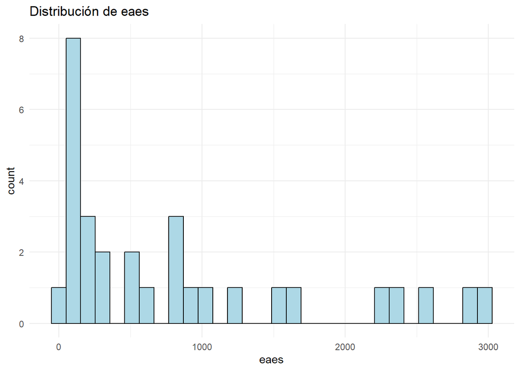

```r
library(ggplot2)
# Gráfico de densidad y histograma para la variable eaes
ggplot(datos, aes(x = aedes))  +
  geom_histogram( fill = "lightblue", color = "black") +
  labs(title = "Distribución de eaes",
       x = "eaes") +
  theme_minimal()
```

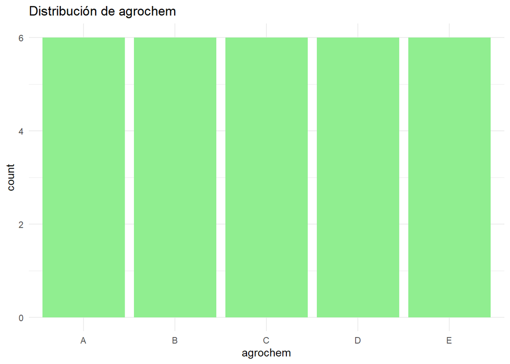

```r
# Gráfico de barras para la variable agrochem
ggplot(datos, aes(x = agrochem)) +
  geom_bar(fill = "lightgreen") +
  labs(title = "Distribución de agrochem",
       x = "agrochem") +
  theme_minimal()
```

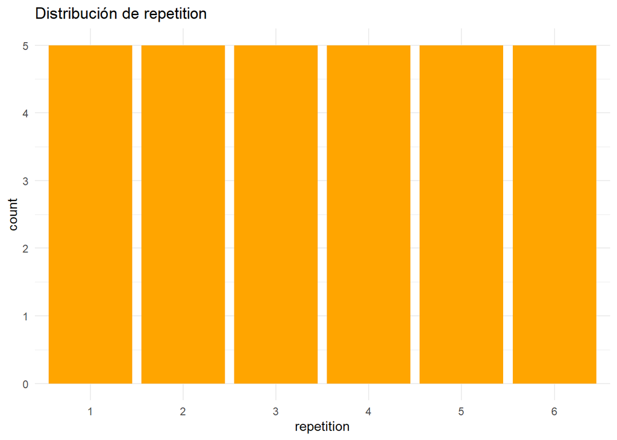

```r
# Gráfico de barras para la variable repetition
ggplot(datos, aes(x = repetition)) +
  geom_bar(fill = "orange") +
  labs(title = "Distribución de repetition",
       x = "repetition") +
  theme_minimal()
```

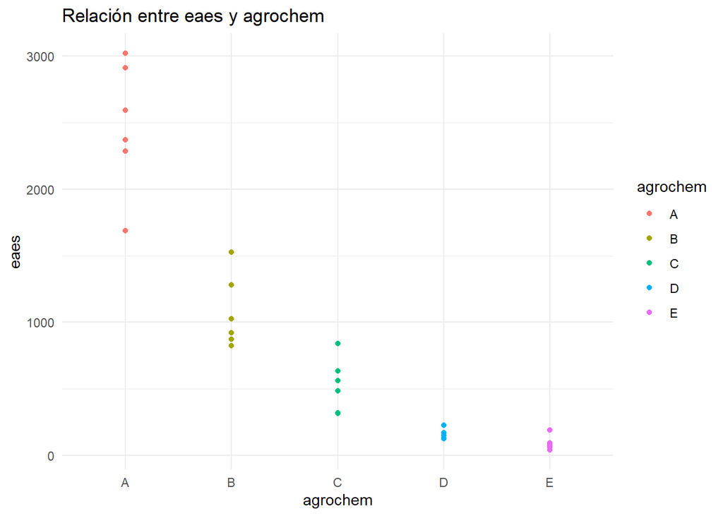

```r
# Gráfico de dispersión para ver la relación entre eaes y agrochem
ggplot(datos, aes(x = agrochem, y = aedes, color = agrochem)) +
  geom_point() +
  labs(title = "Relación entre eaes y agrochem",
       x = "agrochem",
       y = "eaes") +
  theme_minimal()
```

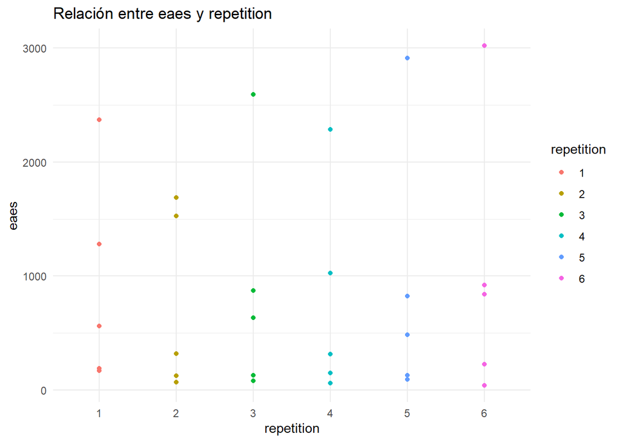

```r
# Gráfico de dispersión para ver la relación entre eaes y repetition
ggplot(datos, aes(x = repetition, y =aedes, color = repetition)) +
  geom_point() +
  labs(title = "Relación entre eaes y repetition",
       x = "repetition",
       y = "eaes") +
  theme_minimal()
```

2. Planteamiento de hipótesis.

AEDES:La variable de respuesta sigue una distribución de Poisson en función de los predictores agrochem y repetition.

Agrochem:El tipo de agroquímico utilizado (agrochem) está relacionado con la efectividad del tratamiento agrícola (aedes) y la repetición del experimento (repetition).(Regresion logistica ordinal)

Repetition: La variable ordinal repetition (con 6 niveles) está relacionada con los cambios en los niveles ordenados en función de los predictores agrochem y eaes. Ambas variables explican las diferencias en las probabilidades de pasar de un nivel a otro en repetition.(Regresion logistica ordinal)

3. Análisis de regresión

AEDES

```r
library(MASS)
# Ajusta el modelo GLM Poisson
modelo_poisson <- glm(aedes ~ agrochem + repetition, data = datos, family = poisson)

# Muestra un resumen del modelo
summary(modelo_poisson)
```

```
##
## Call:
## glm(formula = aedes ~ agrochem + repetition, family = poisson,
##     data = datos)
##
## Coefficients:
##             Estimate Std. Error z value Pr(>|z|)
## (Intercept)  7.87167    0.01572 500.754  < 2e-16 ***
## agrochemB   -0.83473    0.01491 -55.982  < 2e-16 ***
## agrochemC   -1.54729    0.01958 -79.017  < 2e-16 ***
## agrochemD   -2.76281    0.03367 -82.066  < 2e-16 ***
## agrochemE   -3.30029    0.04350 -75.873  < 2e-16 ***
## repetition2 -0.20449    0.02205  -9.274  < 2e-16 ***
## repetition3 -0.06007    0.02122  -2.831  0.00464 **
## repetition4 -0.17701    0.02189  -8.088 6.06e-16 ***
## repetition5 -0.02992    0.02105  -1.421  0.15532
## repetition6  0.09828    0.02040   4.817 1.45e-06 ***
## ---
## Signif. codes:  0 '***' 0.001 '**' 0.01 '*' 0.05 '.' 0.1 ' ' 1
##
## (Dispersion parameter for poisson family taken to be 1)
##
##     Null deviance: 26630.9  on 29  degrees of freedom
## Residual deviance:  1106.8  on 20  degrees of freedom
## AIC: 1364.3
##
## Number of Fisher Scoring iterations: 4
```

```r
# Muestra los coeficientes estimados y las pruebas de significancia
coef(modelo_poisson)
```

```
## (Intercept)   agrochemB   agrochemC   agrochemD   agrochemE repetition2
##  7.87166648 -0.83472749 -1.54728668 -2.76281295 -3.30028761 -0.20448680
## repetition3 repetition4 repetition5 repetition6
## -0.06006528 -0.17700819 -0.02991913  0.09828313
```

AGROCHEMMm

```r
#install.packages("ordinal")
library(ordinal)


# Convierte 'agrochem' y 'repetition' en factores ordenados si no lo están
datos$agrochem <- ordered(datos$agrochem)
datos$repetition <- ordered(datos$repetition)

# Ajusta el modelo de regresión logística ordinal utilizando la familia 'ordinal'
modelo_ordinal <- clm(agrochem ~ aedes + repetition, data = datos)
# Muestra un resumen del modelo
summary(modelo_ordinal)
```

```
## formula: agrochem ~ aedes + repetition
## data:    datos
##
##  link  threshold nobs logLik AIC   niter max.grad cond.H
##  logit flexible  30   -3.39  26.78 13(0) 3.02e-09 7.4e+08
##
## Coefficients:
##              Estimate Std. Error z value Pr(>|z|)
## aedes        -0.10661    0.05004  -2.131   0.0331 *
## repetition.L  1.13091    3.66031   0.309   0.7573
## repetition.Q  9.53732    6.36393   1.499   0.1340
## repetition.C -0.24707    3.57987  -0.069   0.9450
## repetition^4  3.44403    4.10761   0.838   0.4018
## repetition^5 -0.41716    5.17048  -0.081   0.9357
## ---
## Signif. codes:  0 '***' 0.001 '**' 0.01 '*' 0.05 '.' 0.1 ' ' 1
##
## Threshold coefficients:
##     Estimate Std. Error z value
## A|B -174.979     96.398  -1.815
## B|C  -86.697     41.013  -2.114
## C|D  -27.955     51.019  -0.548
## D|E  -14.213      6.939  -2.048
```

```r
# Muestra los coeficientes estimados y las pruebas de significancia
coef(modelo_ordinal)
```

```
##          A|B          B|C          C|D          D|E        aedes repetition.L
## -174.9785567  -86.6971664  -27.9546396  -14.2129186   -0.1066083    1.1309087
## repetition.Q repetition.C repetition^4 repetition^5
##    9.5373220   -0.2470658    3.4440302   -0.4171612
```

REPETITION

```r
# Ajusta el modelo de regresión logística ordinal utilizando la función 'clm'
modelo_ordinal_repetition <- clm(repetition ~ agrochem + aedes, data = datos)
# Muestra un resumen del modelo
summary(modelo_ordinal_repetition)
```

```
## formula: repetition ~ agrochem + aedes
## data:    datos
##
##  link  threshold nobs logLik AIC    niter max.grad cond.H
##  logit flexible  30   -53.35 126.70 4(0)  2.09e-12 2.0e+08
##
## Coefficients:
##             Estimate Std. Error z value Pr(>|z|)
## agrochem.L  2.084287   2.393718   0.871    0.384
## agrochem.Q -0.901081   1.221882  -0.737    0.461
## agrochem.C  0.202122   0.766332   0.264    0.792
## agrochem^4 -0.092014   0.733085  -0.126    0.900
## aedes       0.001183   0.001300   0.910    0.363
##
## Threshold coefficients:
##     Estimate Std. Error z value
## 1|2  -0.6445     1.1558  -0.558
## 2|3   0.2773     1.1282   0.246
## 3|4   0.9816     1.1371   0.863
## 4|5   1.6905     1.1655   1.450
## 5|6   2.6399     1.2450   2.120
```

```r
# Muestra los coeficientes estimados y las pruebas de significancia
coef(modelo_ordinal_repetition)
```

```
##          1|2          2|3          3|4          4|5          5|6   agrochem.L
## -0.644532974  0.277316801  0.981607753  1.690452161  2.639916704  2.084287095
##   agrochem.Q   agrochem.C   agrochem^4        aedes
## -0.901080576  0.202122154 -0.092013526  0.001182924
```

4. Planteamiento del modelo.
5. Validez del modelo. AEDES

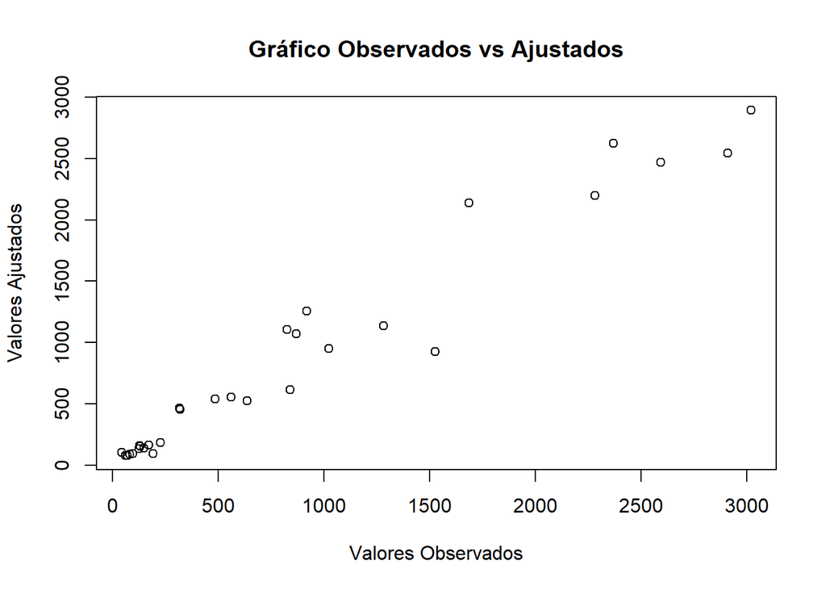

```r
# Obtener valores observados
valores_observed <- datos$aedes

# Obtener los valores ajustados del modelo Poisson
valores_ajustados <- fitted(modelo_poisson)

# Gráfico de dispersión de valores observados vs valores ajustados
plot(datos$aedes, valores_ajustados, xlab = "Valores Observados", ylab = "Valores Ajustados", main = "Gráfico Observados vs Ajustados")
```

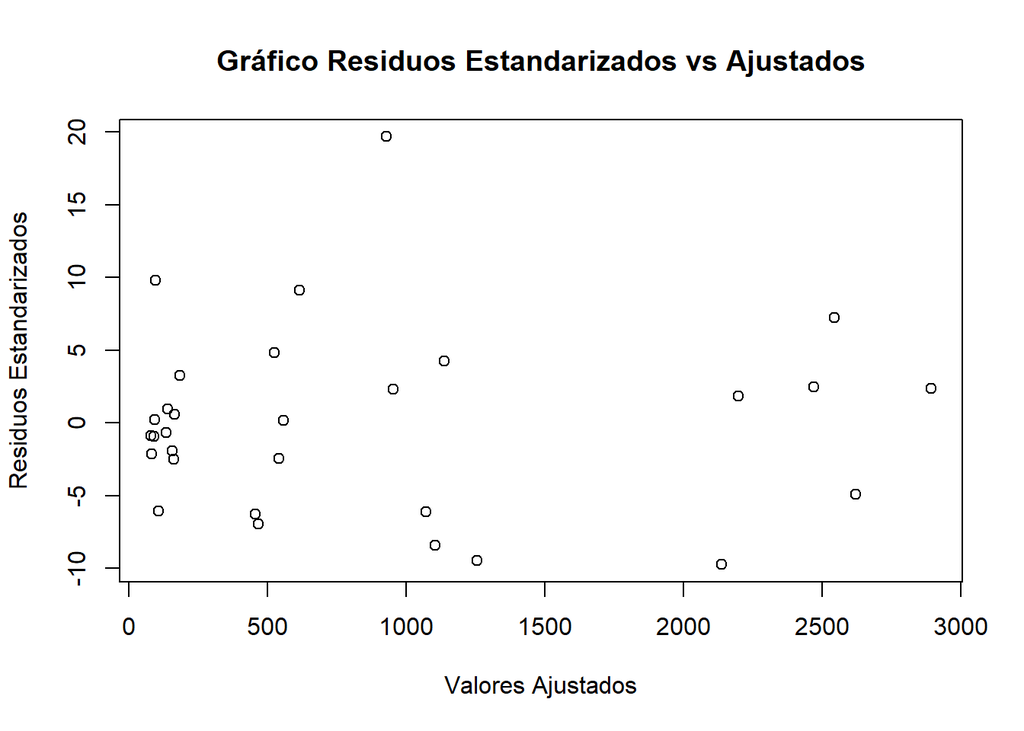

```r
# Gráfico de residuos estandarizados
residuos_estandarizados <- residuals(modelo_poisson, type = "pearson")
plot(valores_ajustados, residuos_estandarizados, xlab = "Valores Ajustados", ylab = "Residuos Estandarizados", main = "Gráfico Residuos Estandarizados vs Ajustados")
```

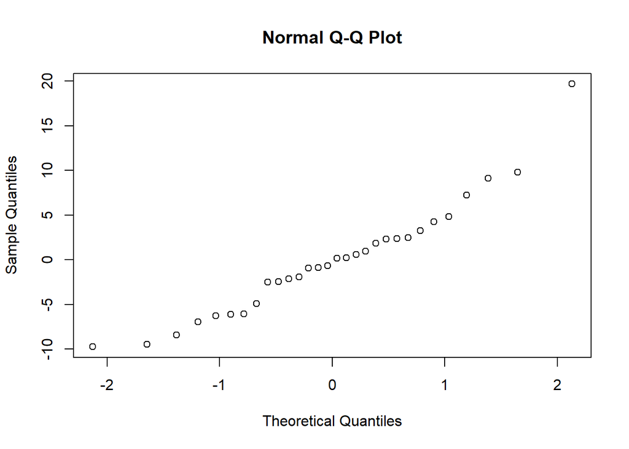

```r
# Gráfico Q-Q
qqnorm(residuos_estandarizados)
```

REPETITION

```r
#install.packages("caret")
library(caret)
# Realizar validación cruzada con 5 repeticiones

cv_results <- train(repetition ~ agrochem + aedes,
  data = datos,
  method = "polr",
  trControl = trainControl(method = "cv", number = 5)
)

# Mostrar los resultados de la validación cruzada
cv_results
```

```
## Ordered Logistic or Probit Regression
##
## 30 samples
##  2 predictor
##  6 classes: '1', '2', '3', '4', '5', '6'
##
## No pre-processing
## Resampling: Cross-Validated (5 fold)
## Summary of sample sizes: 24, 24, 24, 24, 24
## Resampling results across tuning parameters:
##
##   method    Accuracy    Kappa
##   cauchit   0.00000000  -0.20
##   cloglog   0.03333333  -0.16
##   logistic  0.10000000  -0.08
##   loglog    0.06666667  -0.12
##   probit    0.06666667  -0.12
##
## Accuracy was used to select the optimal model using the largest value.
## The final value used for the model was method = logistic.
```

la tabla muestra los resultados de la validación cruzada para un modelo de regresión logística ordinal con 30 muestras, 2 variables predictoras y 6 clases en la variable de respuesta. Se evaluaron diferentes métodos de ajuste, como ‘cauchit’, ‘cloglog’, ‘logistic’, ‘loglog’ y ‘probit’.

Los valores de precisión (Accuracy) y el coeficiente de Kappa (Kappa) son bajos para todos los métodos evaluados, lo que indica que las predicciones del modelo no tienen un buen ajuste a las clases reales.

Dado el tamaño pequeño de la muestra y la cantidad de clases en la variable de respuesta, es posible que el modelo enfrente desafíos para encontrar patrones significativos.

## **PREGUNTA 2: Series de tiempo [3 PUNTOS]**

En el archivo `"ts.xlsx"` tiene tres datos:

- quakes: cantidad de eventos de terremotos por cada año.
- hepatitis: casos de hepatitis por mes entre 2010 y 2017 (acomodar la tabla si es necesario)
- wildfire: cantidad de eventos de incendios forestales por mes entre 2003 y 2017.

Realizar los siguientes análisis y respectivas interpretaciones:

1. Análisis exploratorio: autocorrelación y descomposición, análisis estacional.

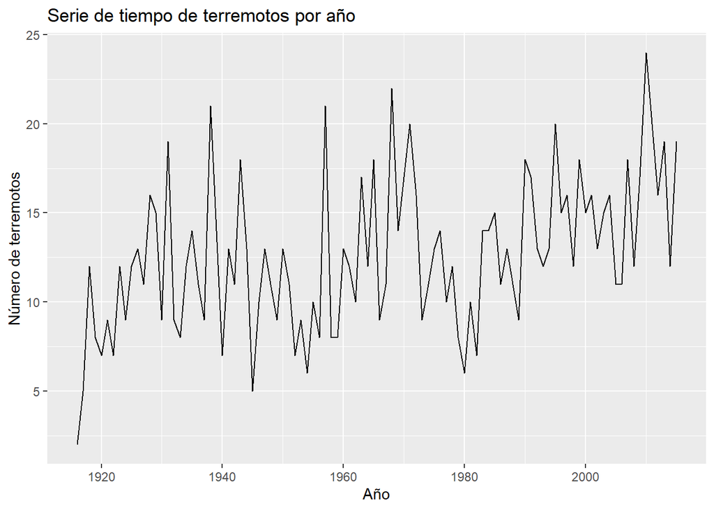

```r
library(readxl)
library(ggplot2)
library(forecast)
ts <- read_excel("C:/Users/HP/Downloads/mce5_exam2-main/mce5_exam2-main/ts.xlsx")

# Gráfico de la serie de tiempo
ggplot(ts, aes(x = year, y = quakes)) +
  geom_line() +
  labs(title = "Serie de tiempo de terremotos por año",
       x = "Año",
       y = "Número de terremotos")
```

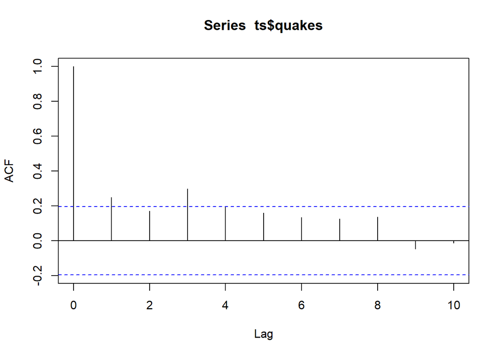

```r
# Análisis de autocorrelación
autocorr <- acf(ts$quakes, lag.max = 10)
```

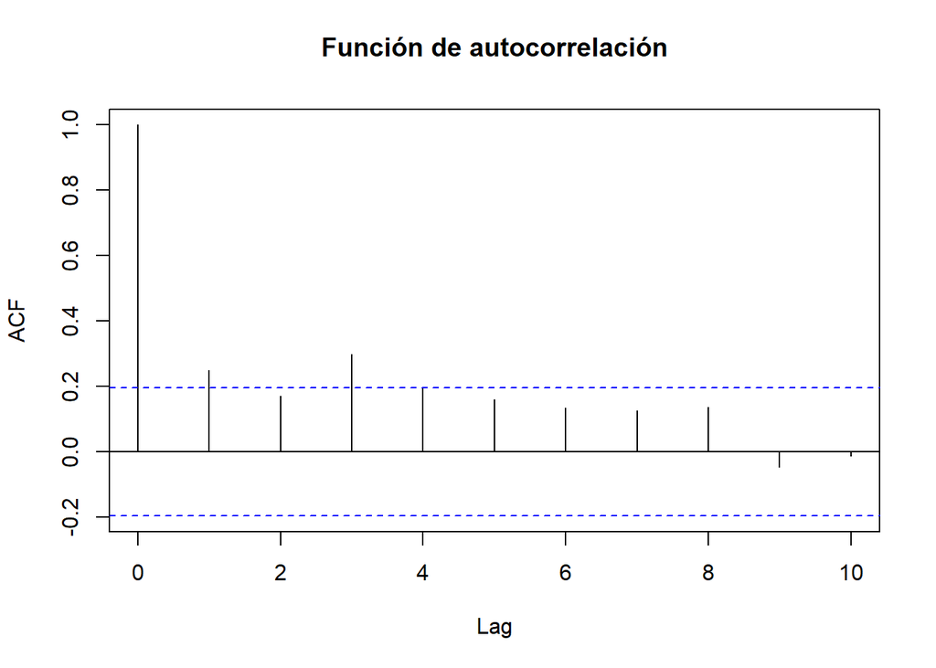

```r
plot(autocorr, main = "Función de autocorrelación")
```

```r
# Descomposición de la serie de tiempo

# Convertir la variable "year" en una serie de tiempo
ts1 <- ts(ts$quakes, start = ts$year[1], frequency = 1)


####Falta de periodos


####Periodos insuficientes
```

2. ARIMA, SARIMA, ETS, NNAR

ETS

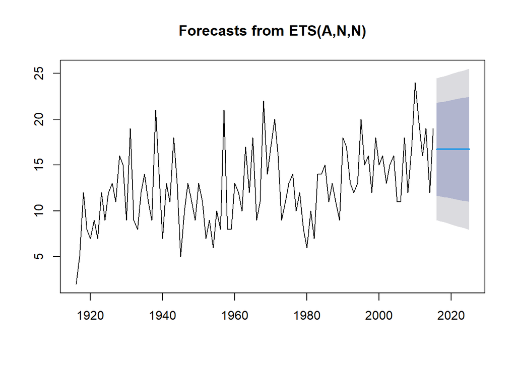

```r
# Convertir las variables "year" y "quakes" en una serie de tiempo
ts <- ts(ts$quakes, start = ts$year[1], frequency = 1)

# Ajustar el modelo ETS
ets_model <- ets(ts)

# Obtener pronósticos
forecast_ets <- forecast(ets_model, h = 10) # n es el número de períodos a pronosticar

# Graficar los pronósticos
plot(forecast_ets)
```

NNAR

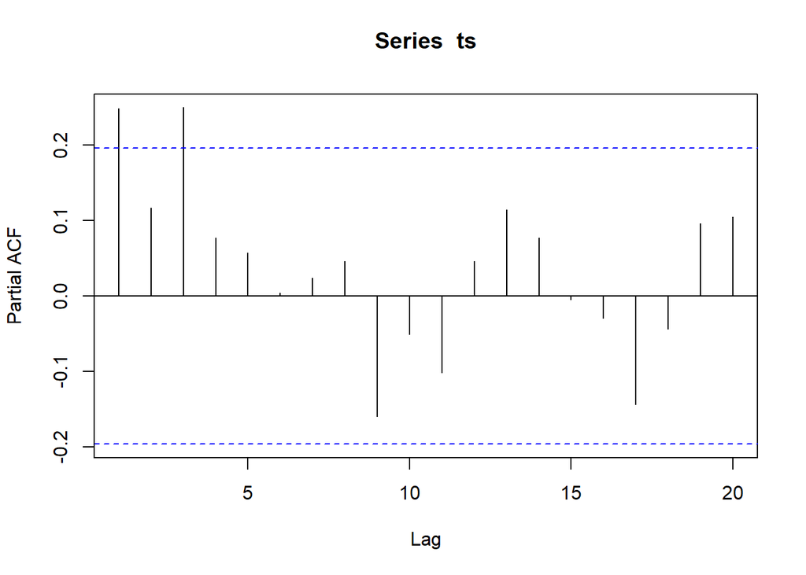

```r
# Calcular la función de autocorrelación parcial (PACF)
pacf_values <- pacf(ts)
```

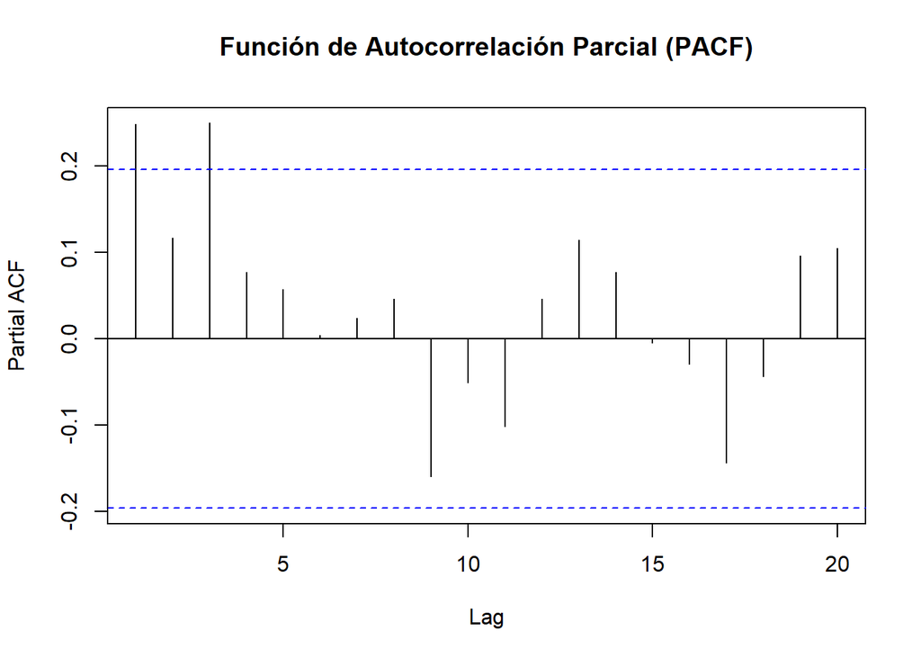

```r
# Graficar la función de autocorrelación parcial
plot(pacf_values, main = "Función de Autocorrelación Parcial (PACF)")
```

```r
nnar_model <- ar(ts, order.max = 2, method = "ols")
nnar_model
```

```
##
## Call:
## ar(x = ts, order.max = 2, method = "ols")
##
## Coefficients:
##      1       2
## 0.1868  0.1279
##
## Intercept: 0.1854 (0.3947)
##
## Order selected 2  sigma^2 estimated as  15.26
```

Los coeficientes son 0.1868 y 0.1279, lo que significa que los valores en los dos tiempos anteriores (lag 1 y lag 2) tienen un efecto positivo en el valor actual de la serie de tiempo. El valor del intercepto es 0.1854.

El valor estimado de la varianza (sigma^2) del modelo es 15.26. Esta es una estimación de la varianza del término de error, lo que indica la dispersión de los errores del modelo y su capacidad para explicar las variaciones en los datos.

3. Validez de los modelos.

```r
# Dividir los datos en conjuntos de entrenamiento y prueba
train_size <- round(0.8 * length(ts))
train <- ts[1:train_size]
test <- ts[(train_size + 1):length(ts)]

# Ajustar el modelo NNAR con k = 2 en los datos de entrenamiento
k <- 2
nnar_model <- ar(train, order.max = k, method = "ols")

# Obtener pronósticos del modelo NNAR en el conjunto de prueba
nnar_forecast <- predict(nnar_model, n.ahead = length(test))

# Calcular métricas de rendimiento para el modelo NNAR
nnar_forecast_ts <- ts(nnar_forecast$pred, start = start(test), frequency = frequency(test))



mse_nnar <- mean((nnar_forecast_ts - test)^2)
mae_nnar <- mean(abs(nnar_forecast_ts - test))
mape_nnar <- mean(abs((nnar_forecast_ts - test) / test)) * 100

# Ajustar el modelo ETS en los datos de entrenamiento
ets_model <- ets(train)

# Obtener pronósticos del modelo ETS en el conjunto de prueba
ets_forecast <- forecast(ets_model, h = length(test))

# Calcular métricas de rendimiento para el modelo ETS
mse_ets <- mean((ets_forecast$mean - test)^2)
mae_ets <- mean(abs(ets_forecast$mean - test))
mape_ets <- mean(abs((ets_forecast$mean - test) / test)) * 100

# Imprimir las métricas de rendimiento para ambos modelos
cat("Métricas de rendimiento para el modelo NNAR:\n")
```

```
## Métricas de rendimiento para el modelo NNAR:
```

```r
cat("MSE:", mse_nnar, "\n")
```

```
## MSE: 24.56161
```

```r
cat("MAE:", mae_nnar, "\n")
```

```
## MAE: 3.888741
```

```r
cat("MAPE:", mape_nnar, "\n\n")
```

```
## MAPE: 21.87274
```

```r
cat("Métricas de rendimiento para el modelo ETS:\n")
```

```
## Métricas de rendimiento para el modelo ETS:
```

```r
cat("MSE:", mse_ets, "\n")
```

```
## MSE: 22.17166
```

```r
cat("MAE:", mae_ets, "\n")
```

```
## MAE: 3.762302
```

```r
cat("MAPE:", mape_ets, "\n")
```

```
## MAPE: 21.41555
```

Los valores de MSE, MAE y MAPE son métricas comunes para evaluar la precisión de los modelos de pronóstico. En este caso, los valores más bajos indican un mejor rendimiento del modelo.

Podemos observar que el modelo ETS tiene un valor de MSE ligeramente más bajo que el modelo NNAR, lo que sugiere que el modelo ETS puede estar proporcionando pronósticos más precisos en comparación con el modelo NNAR.

4. Predicción a 20 años o a 24 meses según corresponda.

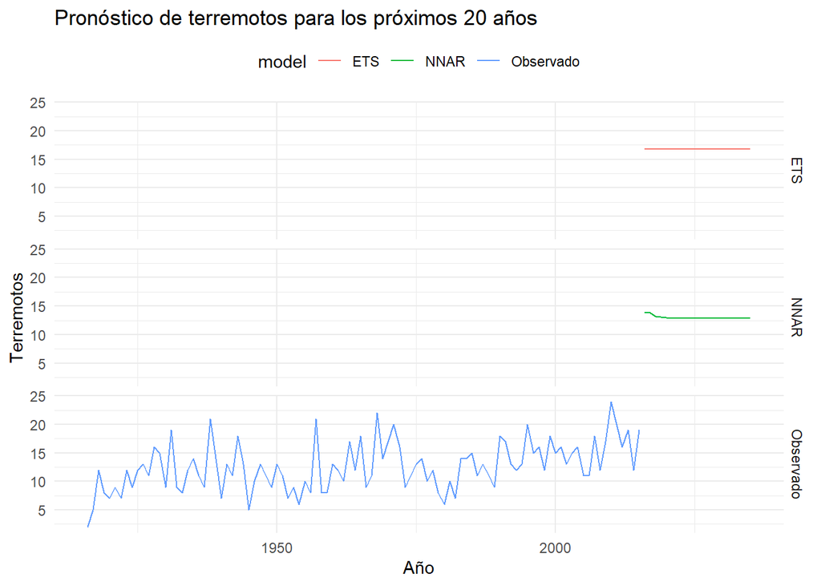

```r
# Ajustar el modelo NNAR con k = 2 en todos los datos
k <- 2
nnar_model <- ar(ts, order.max = k, method = "ols")

# Ajustar el modelo ETS en todos los datos
ets_model <- ets(ts)

# Obtener pronósticos para los próximos 20 años con el modelo NNAR
nnar_forecast <- predict(nnar_model, n.ahead = 20)

# Obtener pronósticos para los próximos 20 años con el modelo ETS
ets_forecast <- forecast(ets_model, h = 20)

forecast_data <- data.frame(
  year = c(time(ts), time(nnar_forecast$pred), time(ets_forecast$mean)),
  value = c(ts, nnar_forecast$pred, ets_forecast$mean),
  model = rep(c("Observado", "NNAR", "ETS"), c(length(ts), length(nnar_forecast$pred), length(ets_forecast$mean)))
)



ggplot(data = forecast_data, aes(x = year, y = value)) +
  geom_line(aes(color = model)) +
  labs(title = "Pronóstico de terremotos para los próximos 20 años",
       x = "Año",
       y = "Terremotos") +
  theme_minimal() +
  theme(legend.position = "top") +
  facet_grid(rows = vars(model))
```

## **PREGUNTA 3: Análisis espacial de especies [3 PUNTOS]**

Seleccione una especie de planta y una especie de animal; asimismo, dos tipos de modelos de predicción (glm, gam, rf, ann, otro):

- Mosquito: *Aedes aegypti*
- Puma: *Puma concolor*
- Coati: *Nasua nasua*
- Tapir: *Tapirus terrestris*
- Jaguar: *Panthera onca*
- Palma de cera: *Ceroxylon quindiuense*
- Ceibo: *Ceiba pentandra*
- Pasiflora: *Passiflora edulis*
- Chirimoya: *Anona cherimola*

Luego realice un análisis espacial de distribución de la especie en Ecuador continental en base a los datos de presencia del GBIF (use rgbif para descargar la data). Explique el resultado y compare la diferencia entre la salida de los dos modelos. En qué regiones los modelos difieren más en la predicción?

```r
# Cargar librerías
library(rgbif)  # Para descargar datos del GBIF
library(dismo)  # Para trabajar con modelos de distribución de especies
library(randomForest)  # Para el modelo de bosques aleatorios

especie <- "Puma concolor"

# Obtener datos de presencia desde el GBIF para Ecuador
# Cargar el paquete rgbif
library(rgbif)

datos_presencia <- occ_search(scientificName = especie,
                              country = "EC",
                              hasCoordinate = TRUE)

# Extraer las coordenadas de latitud y longitud
 latitud <- datos_presencia$data$latitude
  longitud <- datos_presencia$data$longitude

# Crear un data frame con las coordenadas
datos_df <- data.frame(latitude = latitud, longitude = longitud)

# Modelos de distribución de especies

# Modelo glm
library(randomForest)

modelo_rf <- randomForest(presence ~ longitude + latitude, data = datos_df,
                          ntree = 500,
                          mtry = 2,
                          nodesize = 1)

# Modelo de bosques aleatorios (rf)
datos_rf <- randomForest::randomForest(species ~ longitude + latitude,
                                       data = datos_df,
                                       ntree = 500)

# Predecir la distribución de la especie en todo Ecuador continental
extent_ecuador <- extent(-92.0, -75.2, -5.0, 1.4)  # Extensión de Ecuador continental
raster_pred_glm <- predict(modelo_glm, extent_ecuador, n.trees = 500, type = "response")
raster_pred_rf <- predict(datos_rf, extent_ecuador, type = "response")

# Graficar las predicciones
par(mfrow = c(1, 2))
plot(raster_pred_glm, main = "Predicción - Modelo GLM")
plot(raster_pred_rf, main = "Predicción - Modelo Random Forest")
```

```r
library(rgbif)
library(sp)
library(randomForest)
library(mgcv)
```

```r
library(leaflet)

# Especificar la especie seleccionada
especie <- "Anona cherimola"

# Obtener los datos de presencia del GBIF para Ecuador continental
datos_presencia <- occ_search(taxonKey = name_backbone(especie)$speciesKey, country = "EC", hasCoordinate = TRUE, limit = 10000)

# Filtrar y limpiar los datos
datos_presencia <- datos_presencia$data
datos_presencia <- na.omit(datos_presencia[, c("decimalLongitude", "decimalLatitude")])
coordenadas <- data.frame(x = datos_presencia$decimalLongitude, y = datos_presencia$decimalLatitude)

# Dividir los datos en conjuntos de entrenamiento y prueba
set.seed(123)
indices_entrenamiento <- sample(nrow(coordenadas), floor(0.7 * nrow(coordenadas)))
datos_entrenamiento <- coordenadas[indices_entrenamiento, ]
datos_prueba <- coordenadas[-indices_entrenamiento, ]

# Modelado: Bosques Aleatorios (rf)
modelo_rf <- randomForest(x ~ y, data = datos_entrenamiento, ntree = 100)

# Modelado: Generalized Additive Model (gam)
modelo_gam <- gam(y ~ s(x), data = datos_entrenamiento)

# Evaluar el desempeño de los modelos
prediccion_rf <- predict(modelo_rf, newdata = datos_prueba)
oreprediccion_gam <- predict(modelo_gam, newdata = datos_prueba)

# Comparar las predicciones de los modelos
diferencias <- abs(prediccion_rf - oreprediccion_gam)

# Agregar las coordenadas predichas al conjunto de datos de prueba
datos_prueba$pred_rf <- prediccion_rf
datos_prueba$pred_gam <- oreprediccion_gam

# Crear mapa con los puntos de presencia y diferencias de predicción
mapa_presencia <- leaflet(data = datos_prueba) %>%
  addTiles() %>%
  addMarkers(lng = ~x, lat = ~y,
             popup = ~paste("Especie:", especie, "<br>",
                            "Predicción Bosques Aleatorios (rf):", round(pred_rf, 2), "<br>",
                            "Predicción Generalized Additive Model (gam):", round(pred_gam, 2), "<br>",
                            "Diferencia de predicción:", round(diferencias, 2)),
             label = ~especie)

# Visualizar el mapa
mapa_presencia
```

[interactive chart not shown]

```r
require(pacman)
pacman::p_load(rnaturalearthdata, extrafont, showtext, rnaturalearth, cptcity,
               SSDM, ggspatial, raster, terra, rgbif, tidyverse, sf, sp,
               geodata, glue, ggpubr)

g = gc(reset=T)
rm(list=ls())
options(scipen = 999, warn = -1)

# load data
sps = "Passiflora edulis"
occr = occ_data(scientificName = sps, limit = 10e5, hasCoordinate = T,
                hasGeospatialIssue = F)

# Selec datafrane from occr object and filter for a country
occr = occr[[2]]
unique(occr$country) %>%  sort()
```

[output not shown]

[output cut: 40 more lines]

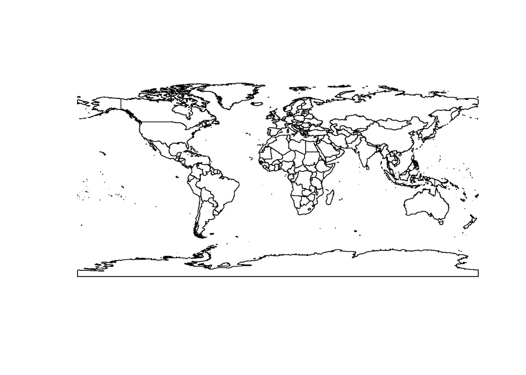

```r
occr = occr %>%  dplyr::filter(country == "Ecuador")

# Get shapefiles
wrld = ne_countries(returnclass = "sf", scale = 50)
ecu1 = geodata::gadm(country = "ECU", level = 1, path = "tmpr")
#ecu_singp =

# Exploratory maps
plot(st_geometry(wrld))
```

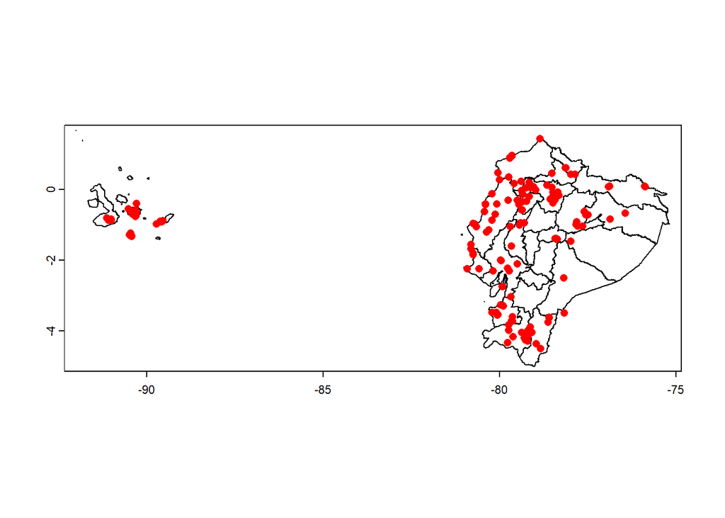

```r
plot(ecu1)
points(occr$decimalLongitude, occr$decimalLatitude, pch = 16, col = "red")
```

```r
# climatic data
bioc = geodata::worldclim_country(country = "ECU", var = "bioc", path = "tmpr")
bioc = terra::crop(bioc, ecu1) %>% terra::mask(., ecu1)
names(bioc) = glue("bioc{1:19}")

# Merge coordinates and bioclimatic data
occr = occr %>%  dplyr::select(x = decimalLongitude, y = decimalLatitude)
vles = terra::extract(bioc, occr[,c("x", "y")])
occr = cbind(occr[,c("x", "y")], vles[,-1])
occr = as_tibble(occr)
occr = mutate(occr, pb = 1)

# Generate backgroun
cell = terra::extract(bioc[[1]], occr[,1:2], cells=T)$cell
duplicated(cell)
```

[output not shown]

```r
mask = bioc[[1]]*0
mask[cell] = NA
back = terra::as.data.frame(mask, xy =T) %>% as_tibble()
back = sample_n(back, size = nrow(occr)*2, replace = FALSE)
colnames(back)[3] = "pb"
back = mutate(back, pb = 0)
back = cbind(back, terra::extract(bioc, back[,c(1,2)])[,-1])
back = as_tibble(back)

# Join data
tble = rbind(occr, back)

# GLM Model
bioc = stack(bioc)
```

[output not shown]

```r
tble = as.data.frame(tble)

srdf = modelling(algorithm = "GLM", Env = bioc, Occurrences = tble, Pcol = "pb",
                 Xcol = "x", cv.parm = c(0.75, 0.25),
                 Ycol = "y", metric = "TSS", select.metric = "AUC")
```

```
## Data check ...
##    done.
##
## Model evaluation...
##    done.
##
## Model projection...
##    done.
##
## Model axes contribution evaluation...
##    done.
```

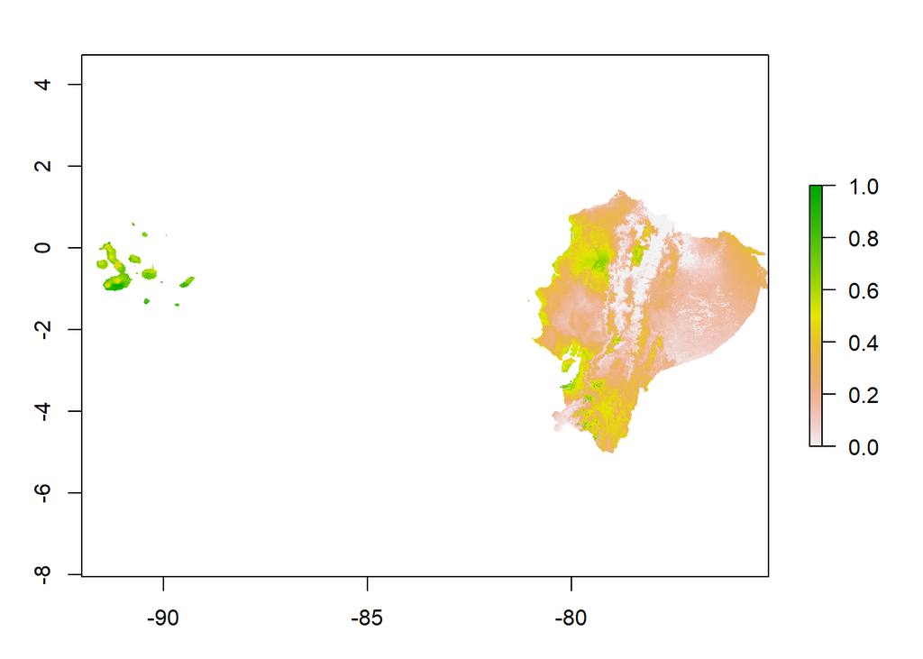

```r
plot(srdf@projection)
```